# Apoyo para la preparación de datos de la PD02: matriz de comunidad y matriz ambiental Biogeografía (GEO-131) Universidad Autónoma de Santo Domingo (UASD) Semestre 2025-01

El Tali

2025-03-04

# Generar las matrices de comunidad y ambiental

Creé funciones de ayuda para generar las matrices de comunidad y ambiental a partir de datos de GBIF (GBIF.org, 2022) y el repositorio de estadística zonal sobre RD de Martínez-Batlle (2022), usando como índice espacial hexágonos de la biblioteca H3. Todas las funciones de ayuda las encapsulé en una tubería o toolchain denominado `generar_mc_ma`. Ejemplos de uso a continuación.

# Funciones

Primero cargo las funciones con el `source` del siguiente bloque de código.

```r
source('matrices-de-comunidad-y-ambiental.R')
```

# Evaluación de la función para una familia, Acanthaceae

## Evaluar la función propiamente

A modo de ejemplo, a continuación genero las matrices de comunidad y ambiental de la familia Acanthaceae evaluando la función `generar_mc_ma`.

```r
# Llamada a la función
acanthaceae <- generar_mc_ma(
  taxon = 'Acanthaceae',
  exportar_sf = T,
  exportar_mc = T,
  min_num_spp_hex = 2,
  min_num_hex_sp = 2)
```

```
##
##
## ### CREANDO ÍNDICE ESPACIAL H3 EN EL ÁREA DE INTERES (AOI) ###
##
##
## ### DESCARGANDO O IMPORTANDO REGISTROS DE PRESENCIA DEL TAXÓN Acanthaceae DESDE GBIF ###
##
##
## ### LIMPIANDO REGISTROS DE PRESENCIA DEL TAXÓN ###
##
##
## ### CONVIRTIENDO REGISTROS DE PRESENCIA A OBJETO sf ###
##
##
## ### INTERSECTANDO REGISTROS DE PRESENCIA EN EL ÍNDICE ESPACIAL ###
##
##
## ### CREANDO GRÁFICO ###
##
##
## ### GENERANDO SALIDAS .RDS DE LOS REGISTROS INTERSECTADOS Y EL ÍNDICE ESPACIAL ###
##
##
## ### GENERANDO SALIDAS .RDS DE LOS REGISTROS INTERSECTADOS Y EL ÍNDICE ESPACIAL ###
## Deleting source `salidas_sf/reg_hex_inter_Acanthaceae.kml' using driver `KML'
## Writing layer `reg_hex_inter_Acanthaceae' to data source
##   `salidas_sf/reg_hex_inter_Acanthaceae.kml' using driver `KML'
## Writing 617 features with 136 fields and geometry type Point.
## Deleting source `salidas_sf/ind_esp_Acanthaceae.kml' using driver `KML'
## Writing layer `ind_esp_Acanthaceae' to data source
##   `salidas_sf/ind_esp_Acanthaceae.kml' using driver `KML'
## Writing 291 features with 1 fields and geometry type Polygon.
##
##
## ### GENERANDO MATRIZ DE COMUNIDAD ###
## El número de especies quitadas de la matriz por estar en menos de 2 hexágonos fue de  29
## El número de hexágonos quitados de la matriz por tener menos de 2 expecies representadas fue de 67
##
##
## ### EXPORTANDO MATRIZ DE COMUNIDAD DE NOMBRES LARGOS Y CORTOS EN FORMATO .RDS ###
##
##
## ### GENERANDO MATRIZ AMBIENTAL ###
## Hay consistencia de filas entre matrices de comunidad y ambiental
##
##
## ### EXPORTANDO MATRIZ AMBIENTAL ###
##
##
## ### GENERANDO LISTA EXHAUSTIVA DE OBJETOS ###
##
##
## ### MATRICES DE COMUNIDAD Y AMBIENTAL GENERADAS CON ÉXITO ###
```

Si la función se ejecutó correctamente, los directorios `salidas_RDS` y `salidas_sf` contienen archivos geográficos en formato `.RDS` y `.kml` (para abrir en QGIS o Google Earth) de los registros de presencia de GBIF, así como índice espacial de hexágonos H3. Los directorios `salidas_mc` y `salidas_ma` contienen archivos en formato `.RDS` de la matrices de comunidad y ambiental para cada taxon, respectivamente.

## Mapa

El objeto `acanthaceae` contiene todos los objetos creados por el *toolchain*. Uno de ellos consiste en un mapa de distribución de los registros de presencia de GBIF para el taxón, y los hexágonos de la biblioteca H3.

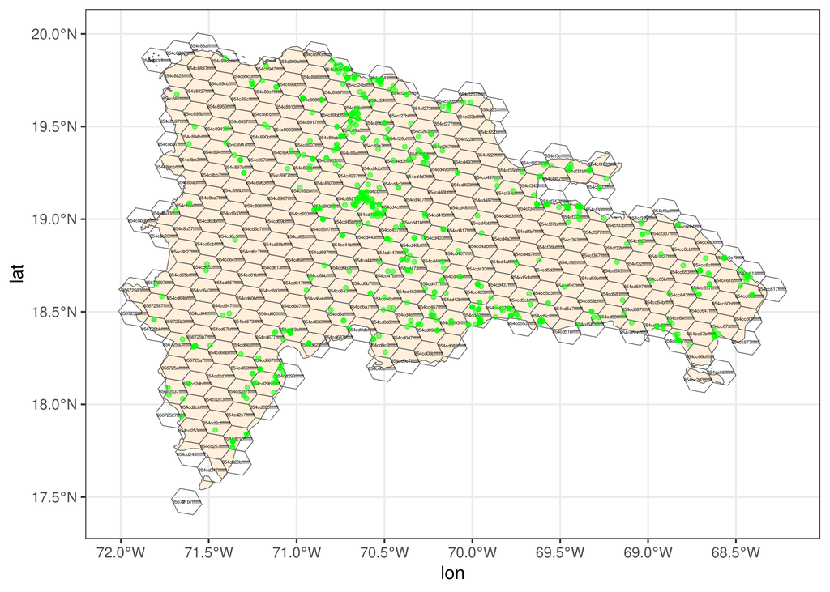

```r
# Mapa
acanthaceae$aoi_reg_hex_inter_g
```

La matriz de comunidad se puede imprimir con la función `kable` del paquete `kableExtra`.

```r
acanthaceae$mc %>% kableExtra::kable()
```

|  | Thunbergia alata Bojer ex Sims | Thunbergia fragrans Roxb. | Barleria lupulina Lindl. | Megaskepasma erythrochlamys Lindau | Justicia pilosella (Nees) Hilsenb. | Ruellia simplex C.Wright | Pachystachys lutea (Ruiz & Pav. ex Schult.) Nees | Thunbergia grandiflora (Roxb. ex Rottler) Roxb. | Odontonema cuspidatum (Nees) Kuntze | Asystasia gangetica (L.) T.Anderson | Ruellia ciliatiflora Hook. | Ruellia tuberosa L. | Ruellia coccinea (L.) Vahl | Ruellia blechum L. | Pachystachys spicata (Ruiz & Pav.) Wassh. | Barleriola solanifolia (L.) Oerst. ex Lindau | Oplonia spinosa (Jacq.) Raf. | Dianthera secunda (Lam.) Griseb. | Avicennia germinans (L.) L. | Andrographis paniculata (Burm.fil.) Nees | Dianthera pectoralis (Jacq.) J.F.Gmel. | Sanchezia parvibracteata Sprague & Hutch. | Crossandra infundibuliformis (L.) Nees | Graptophyllum pictum (L.) Griff. | Thunbergia erecta (Benth.) T.Anderson | Justicia brandegeeana Wassh. & L.B.Sm. | Dicliptera mucronata Urb. | Oplonia microphylla (Lam.) Stearn | Ruellia domingensis Spreng. ex Nees | … |
| --- | --- | --- | --- | --- | --- | --- | --- | --- | --- | --- | --- | --- | --- | --- | --- | --- | --- | --- | --- | --- | --- | --- | --- | --- | --- | --- | --- | --- | --- | --- |
| 854cd4cbfffffff | 1 | 1 | 0 | 1 | 0 | 1 | 0 | 1 | 1 | 0 | 0 | 0 | 0 | 0 | 0 | 0 | 0 | 0 | 0 | 0 | 0 | 0 | 1 | 0 | 1 | 0 | 0 | 0 | 1 | … |
| 854c8927fffffff | 1 | 1 | 0 | 0 | 0 | 0 | 1 | 0 | 0 | 0 | 0 | 1 | 0 | 0 | 0 | 0 | 0 | 0 | 0 | 0 | 0 | 0 | 1 | 0 | 0 | 0 | 0 | 0 | 0 | … |
| 85672537fffffff | 0 | 0 | 1 | 0 | 0 | 0 | 0 | 0 | 0 | 0 | 0 | 1 | 0 | 0 | 0 | 0 | 1 | 0 | 0 | 0 | 0 | 0 | 0 | 0 | 0 | 0 | 0 | 0 | 0 | … |
| 854c89abfffffff | 0 | 0 | 1 | 0 | 1 | 1 | 0 | 0 | 0 | 1 | 0 | 0 | 0 | 1 | 0 | 0 | 0 | 0 | 0 | 0 | 0 | 0 | 0 | 0 | 0 | 0 | 0 | 0 | 0 | … |
| 854c8933fffffff | 0 | 1 | 0 | 0 | 0 | 1 | 0 | 0 | 0 | 0 | 0 | 0 | 0 | 0 | 0 | 0 | 0 | 0 | 0 | 0 | 0 | 0 | 0 | 0 | 0 | 0 | 0 | 0 | 1 | … |
| 854c8997fffffff | 1 | 1 | 0 | 1 | 0 | 1 | 1 | 1 | 0 | 1 | 1 | 0 | 0 | 0 | 0 | 0 | 1 | 0 | 1 | 0 | 0 | 0 | 0 | 1 | 0 | 1 | 0 | 1 | 0 | … |
| 854cf247fffffff | 1 | 0 | 0 | 0 | 0 | 1 | 0 | 0 | 0 | 0 | 0 | 0 | 0 | 0 | 0 | 0 | 0 | 0 | 0 | 0 | 0 | 0 | 0 | 0 | 0 | 0 | 0 | 0 | 0 | … |
| 854cd29bfffffff | 0 | 0 | 0 | 0 | 0 | 0 | 0 | 0 | 1 | 0 | 0 | 0 | 1 | 0 | 0 | 1 | 0 | 0 | 0 | 0 | 1 | 0 | 0 | 0 | 0 | 0 | 0 | 0 | 0 | … |
| 854cd477fffffff | 1 | 0 | 0 | 1 | 0 | 0 | 0 | 1 | 0 | 0 | 0 | 0 | 0 | 0 | 0 | 0 | 0 | 0 | 0 | 0 | 0 | 0 | 1 | 0 | 0 | 0 | 0 | 0 | 0 | … |
| 854cd46bfffffff | 0 | 0 | 0 | 0 | 0 | 0 | 0 | 0 | 0 | 0 | 0 | 0 | 0 | 0 | 0 | 0 | 0 | 0 | 0 | 0 | 0 | 0 | 0 | 0 | 0 | 0 | 0 | 0 | 0 | … |
| 854c89b3fffffff | 1 | 1 | 0 | 1 | 0 | 0 | 1 | 0 | 1 | 0 | 0 | 1 | 0 | 0 | 0 | 0 | 0 | 1 | 0 | 0 | 0 | 0 | 0 | 0 | 0 | 0 | 0 | 0 | 0 | … |
| 854cd40bfffffff | 0 | 0 | 0 | 0 | 0 | 0 | 0 | 0 | 1 | 0 | 0 | 0 | 0 | 1 | 0 | 0 | 0 | 0 | 0 | 0 | 0 | 0 | 0 | 0 | 0 | 0 | 0 | 0 | 0 | … |
| 854cf373fffffff | 1 | 0 | 0 | 0 | 0 | 0 | 0 | 0 | 1 | 0 | 0 | 0 | 0 | 0 | 0 | 0 | 0 | 0 | 1 | 0 | 0 | 0 | 0 | 0 | 0 | 0 | 0 | 0 | 0 | … |
| 854cd423fffffff | 1 | 0 | 0 | 0 | 0 | 1 | 0 | 0 | 0 | 0 | 0 | 0 | 0 | 0 | 0 | 0 | 1 | 0 | 0 | 0 | 0 | 0 | 0 | 0 | 0 | 0 | 0 | 1 | 1 | … |
| 854cc6c7fffffff | 0 | 0 | 0 | 0 | 0 | 1 | 0 | 0 | 0 | 0 | 0 | 1 | 0 | 0 | 0 | 0 | 0 | 0 | 0 | 0 | 0 | 0 | 1 | 0 | 0 | 0 | 0 | 0 | 0 | … |
| 854c892ffffffff | 0 | 0 | 0 | 0 | 0 | 1 | 0 | 0 | 1 | 0 | 0 | 0 | 1 | 0 | 0 | 0 | 0 | 0 | 0 | 0 | 0 | 0 | 0 | 0 | 0 | 0 | 0 | 0 | 0 | … |
| 854cd63bfffffff | 0 | 0 | 0 | 0 | 0 | 0 | 0 | 0 | 0 | 0 | 1 | 0 | 0 | 0 | 0 | 0 | 0 | 0 | 0 | 0 | 0 | 0 | 0 | 0 | 0 | 0 | 1 | 0 | 0 | … |
| 854cd457fffffff | 0 | 0 | 0 | 0 | 0 | 0 | 0 | 1 | 0 | 0 | 0 | 0 | 0 | 0 | 1 | 0 | 0 | 0 | 0 | 0 | 0 | 0 | 0 | 0 | 0 | 0 | 0 | 0 | 0 | … |
| 856725b7fffffff | 0 | 0 | 0 | 1 | 0 | 1 | 0 | 0 | 0 | 1 | 0 | 0 | 0 | 0 | 0 | 1 | 1 | 0 | 0 | 0 | 0 | 0 | 0 | 0 | 0 | 0 | 0 | 0 | 0 | … |
| 854cf26ffffffff | 1 | 1 | 0 | 0 | 0 | 1 | 0 | 0 | 0 | 1 | 0 | 1 | 0 | 1 | 0 | 0 | 0 | 0 | 0 | 0 | 0 | 0 | 0 | 0 | 0 | 0 | 0 | 0 | 0 | … |
| 854c89a3fffffff | 0 | 0 | 1 | 0 | 0 | 1 | 0 | 1 | 1 | 0 | 0 | 1 | 0 | 0 | 0 | 0 | 0 | 0 | 0 | 0 | 0 | 0 | 0 | 1 | 0 | 0 | 0 | 0 | 0 | … |
| 854cd647fffffff | 0 | 0 | 0 | 0 | 0 | 1 | 0 | 0 | 0 | 0 | 0 | 1 | 0 | 0 | 0 | 0 | 0 | 0 | 0 | 0 | 0 | 0 | 0 | 0 | 0 | 0 | 0 | 0 | 0 | … |
| 854cd453fffffff | 1 | 0 | 0 | 0 | 0 | 0 | 0 | 1 | 1 | 0 | 0 | 0 | 0 | 0 | 0 | 0 | 0 | 0 | 0 | 0 | 0 | 0 | 0 | 0 | 0 | 0 | 0 | 0 | 0 | … |
| 854c89c7fffffff | 0 | 0 | 1 | 0 | 0 | 0 | 0 | 0 | 0 | 0 | 0 | 1 | 0 | 0 | 0 | 0 | 0 | 0 | 0 | 0 | 0 | 0 | 0 | 0 | 0 | 0 | 0 | 0 | 0 | … |
| 854c89c3fffffff | 0 | 0 | 1 | 0 | 0 | 0 | 0 | 0 | 0 | 0 | 0 | 0 | 0 | 0 | 0 | 0 | 0 | 0 | 0 | 0 | 0 | 0 | 0 | 0 | 0 | 0 | 0 | 0 | 0 | … |
| 854c8907fffffff | 0 | 0 | 0 | 0 | 1 | 0 | 0 | 0 | 0 | 0 | 0 | 0 | 0 | 0 | 0 | 0 | 0 | 0 | 0 | 0 | 0 | 0 | 0 | 0 | 0 | 0 | 0 | 0 | 0 | … |
| 854cf347fffffff | 1 | 0 | 0 | 0 | 0 | 0 | 0 | 0 | 0 | 0 | 0 | 0 | 1 | 0 | 0 | 0 | 0 | 0 | 1 | 0 | 0 | 0 | 0 | 0 | 0 | 0 | 0 | 0 | 0 | … |
| 854cd4bbfffffff | 0 | 0 | 0 | 1 | 0 | 0 | 0 | 0 | 1 | 0 | 0 | 0 | 0 | 0 | 0 | 0 | 0 | 0 | 0 | 0 | 0 | 0 | 0 | 0 | 0 | 0 | 0 | 0 | 0 | … |
| 854cf24bfffffff | 1 | 1 | 0 | 0 | 0 | 0 | 1 | 1 | 0 | 0 | 0 | 0 | 0 | 0 | 0 | 0 | 0 | 0 | 0 | 0 | 0 | 0 | 0 | 0 | 0 | 0 | 0 | 0 | 0 | … |
| 854cd0c3fffffff | 0 | 0 | 0 | 1 | 0 | 0 | 0 | 0 | 0 | 0 | 1 | 0 | 0 | 0 | 0 | 0 | 1 | 0 | 0 | 0 | 0 | 0 | 0 | 0 | 0 | 0 | 0 | 0 | 0 | … |

[output cut: 54 more lines]

## Resumen de la matriz de comunidad y ambiental

Finalmente, un método de la función `summary` genera un resumen básico de los datos de comunidad.

```r
summary.mc_ma(acanthaceae, nombres_cortos = F, tamano_rotulo = 6)
```

- **Lista de especies en orden alfabético**

| Especies |
| --- |
| Andrographis paniculata (Burm.fil.) Nees |
| Asystasia gangetica (L.) T.Anderson |
| Avicennia germinans (L.) L. |
| Barleria lupulina Lindl. |
| Barleriola inermis Urb. & Ekman |
| Barleriola solanifolia (L.) Oerst. ex Lindau |
| Crossandra infundibuliformis (L.) Nees |
| Dianthera pectoralis (Jacq.) J.F.Gmel. |
| Dianthera reptans (Sw.) J.F.Gmel. |
| Dianthera secunda (Lam.) Griseb. |
| Dianthera sessilis (Jacq.) J.F.Gmel. |
| Dicliptera mucronata Urb. |
| Dyschoriste diffusa (Nees) Urb. |
| Graptophyllum pictum (L.) Griff. |
| Hygrophila costata Nees |
| Justicia alsinoides Leonard |
| Justicia brandegeeana Wassh. & L.B.Sm. |
| Justicia disparifolia Urb. & Ekman |
| Justicia mirabiloides Lam. |
| Justicia pilosella (Nees) Hilsenb. |
| Lepidagathis alopecuroidea (Vahl) R.Br. ex Griseb. |
| Megaskepasma erythrochlamys Lindau |
| Odontonema cuspidatum (Nees) Kuntze |
| Oplonia acicularis (Sw.) Stearn |
| Oplonia microphylla (Lam.) Stearn |
| Oplonia spinosa (Jacq.) Raf. |
| Pachystachys lutea (Ruiz & Pav. ex Schult.) Nees |
| Pachystachys spicata (Ruiz & Pav.) Wassh. |
| Ruellia blechum L. |
| Ruellia ciliatiflora Hook. |
| Ruellia coccinea (L.) Vahl |
| Ruellia domingensis Spreng. ex Nees |
| Ruellia geminiflora Kunth |
| Ruellia lepidota Urb. |
| Ruellia simplex C.Wright |
| Ruellia tuberosa L. |
| Sanchezia parvibracteata Sprague & Hutch. |
| Stenandrium tuberosum (L.) Urb. |
| Thunbergia alata Bojer ex Sims |
| Thunbergia erecta (Benth.) T.Anderson |
| Thunbergia fragrans Roxb. |
| Thunbergia grandiflora (Roxb. ex Rottler) Roxb. |

- **Las matrices de comunidad y ambiental abarcan** 84 **sitios (hexágonos)**
- **La riqueza es 42 especies**
- **Riqueza de especies por sitios**

| Hexágono H3 | Riqueza de especies |
| --- | --- |
| 854cd4cbfffffff | 11 |
| 854c8927fffffff | 6 |
| 85672537fffffff | 3 |
| 854c89abfffffff | 5 |
| 854c8933fffffff | 4 |
| 854c8997fffffff | 13 |
| 854cf247fffffff | 2 |
| 854cd29bfffffff | 5 |
| 854cd477fffffff | 4 |
| 854cd46bfffffff | 2 |
| 854c89b3fffffff | 7 |
| 854cd40bfffffff | 4 |
| 854cf373fffffff | 3 |
| 854cd423fffffff | 6 |
| 854cc6c7fffffff | 3 |
| 854c892ffffffff | 4 |
| 854cd63bfffffff | 2 |
| 854cd457fffffff | 5 |
| 856725b7fffffff | 6 |
| 854cf26ffffffff | 6 |
| 854c89a3fffffff | 6 |
| 854cd647fffffff | 2 |
| 854cd453fffffff | 7 |
| 854c89c7fffffff | 2 |
| 854c89c3fffffff | 3 |
| 854c8907fffffff | 2 |
| 854cf347fffffff | 4 |
| 854cd4bbfffffff | 2 |
| 854cf24bfffffff | 4 |
| 854cd0c3fffffff | 4 |

[output cut: 54 more lines]

- **Gráfico de mosaicos de presencia de especies por hexágonos H3**

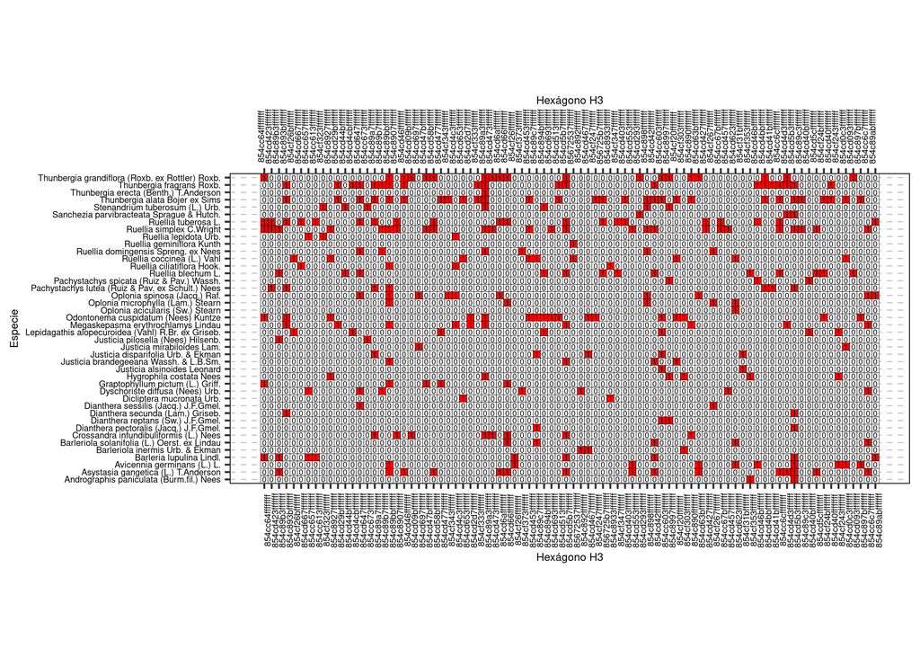

# Procesamiento por lotes de múltiples familias bien representada en GBIF para RD

## Selección de familias

```r
fam_sel <- c('Acanthaceae',
             'Bromeliaceae',
             'Cactaceae',
             'Fabaceae',
             'Myrtaceae',
             'Orchidaceae',
             'Asteraceae',
             'Poaceae',
             'Rubiaceae',
             'Melastomataceae',
             'Piperaceae',
             'Solanaceae',
             'Euphorbiaceae',
             'Tyrannidae',
             'Thraupidae',
             'Phyllostomidae',
             'Eleutherodactylidae',
             'Nymphalidae',
             'Dactyloidae',
             'Formicidae',
             'Sphaerodactylidae',
             'Leiocephalidae',
             'Curculionidae',
             'Cathartidae',
             'Columbidae',
             'Malvaceae',
             'Erebidae',
             'Apocynaceae'
)
fam_sel <- sort(fam_sel)
```

## Evaluar la función propiamente (*be careful*)

El cometido de este bloque de abajo fue realizar una consulta “masiva” a la base de datos de GBIF y obtener registros de presencia para múltiples familias de plantas y animales bien representadas en RD, los cuales son requeridos para realizar la práctica PD02 y se encuentran en los directorios `salidas_*`. Por lo tanto, no es necesario re-ejecutar este bloque, sólo se deja aquí para fines de reproducibilidad.

La consulta tomó varios minutos, y ocupó una buena porción de la RAM. Dado lo compleja de esta operación, la evaluación no se ejecutó con el tejido de este cuaderno (en el RMarkdown, el encabezado del código tiene `eval=F`), sino que se realizó de forma directa ejecutando el bloque de código.

El “*be careful*” en el título está dirigido a personas que tuviesen interés por ejecutar este bloque por cuenta propia (e.g. para otra selección de familias), en cuyo caso hay que tener cuidado de seleccionar apropiadamente un número razonablemente pequeño de familias.

```r
# mc_ma_familias_seleccionadas_l <- sapply(fam_sel, function(x) {
#   tryCatch(
#     {
#       generar_mc_ma(
#         taxon = x,
#         exportar_sf = TRUE,
#         exportar_mc = TRUE
#       )
#     },
#     error = function(e) {
#       message(paste("Error en la familia:", x, ":", e$message))
#       return(NULL)  # Retorna NULL en caso de error
#     })
#   }, simplify = FALSE)
# saveRDS(
#   object = mc_ma_familias_seleccionadas_l,
#   file = 'salidas_RDS/todos_los_objetos_todas_las_familias.RDS') # Añadido al .gitignore
# # Cathartidae y Dactyloidae no funcionaron, descargados por separado
# cathartidae <- generar_mc_ma(
#   taxon = 'Cathartidae',
#   exportar_sf = T,
#   exportar_mc = T)
# dactyloidae <- generar_mc_ma(
#   taxon = 'Dactyloidae',
#   archivo_reg_pres = T,
#   ruta_archivo_reg_pres = 'ignorar/0002860-250227182400228.csv',
#   col_species_como_acceptedScientificName = T,
#   exportar_sf = T,
#   exportar_mc = T)
# Nota: quien use Dactyloidae debe ser consciente de que el archivo de registros de presencia
# usado contenía sólo una columna "species" y no una "acceptedScientificName", lo cual
# no es lo ideal, pero es lo que se tiene.
```

Al realizar la operación masiva anterior, se producen los mismos archivos que produje para el caso de la familia Acanthaceae, a saber: `salidas_RDS`, `salidas_sf`, `salidas_mc` y `salidas_ma`. Los archivos `.kml`, que se guardan en el directorio `salidas_sf` no se incluyeron en esta operación masiva `.kml`, porque son muy grandes (los generé pero no los subí al repo remoto para garantizar la manejabilidad). Recomiendo usar los archivos por familias del directorio `salidas_RDS`, y si se necesitase un `.kml` de registros de presencia depurados, generarlo al momento con el siguiente código (ejemplo para Acanthaceae):

```r
library(sf)
acanthaceae <- readRDS('salidas_RDS/todos_los_objetos_Acanthaceae.RDS')
st_write(
      obj = acanthaceae$reg_pres_sf %>% select(-networkKeys),
      dsn = 'salidas_sf/reg_hex_inter_Acanthaceae.kml',
      delete_dsn = T)
```

A continuación se incluyen algunos resúmenes básicos de todas las familias.

- Número de registros limpios por familia.

```r
registros_desde_rds <- sapply(
  X = fam_sel,
  function(x) {
    nrow(readRDS(paste0('salidas_RDS/reg_hex_inter_', x, '.RDS')))
  }, simplify = F)
plyr::ldply(
  registros_desde_rds) %>%
  setNames(
    c(
      'Familia',
      'Número de registros de presencia en GBIF (limpios)')) %>%
  kable()
```

| Familia | Número de registros de presencia en GBIF (limpios) |
| --- | --- |
| Acanthaceae | 617 |
| Apocynaceae | 1002 |
| Asteraceae | 2896 |
| Bromeliaceae | 1468 |
| Cactaceae | 719 |
| Cathartidae | 5808 |
| Columbidae | 35326 |
| Curculionidae | 2362 |
| Dactyloidae | 14717 |
| Eleutherodactylidae | 4807 |
| Erebidae | 1038 |
| Euphorbiaceae | 1877 |
| Fabaceae | 4076 |
| Formicidae | 6350 |
| Leiocephalidae | 2151 |
| Malvaceae | 1732 |
| Melastomataceae | 2519 |
| Myrtaceae | 1757 |
| Nymphalidae | 3521 |
| Orchidaceae | 1703 |
| Phyllostomidae | 2416 |
| Piperaceae | 1255 |
| Poaceae | 1835 |
| Rubiaceae | 2991 |
| Solanaceae | 1506 |
| Sphaerodactylidae | 2282 |
| Thraupidae | 22334 |
| Tyrannidae | 21904 |

- Riqueza de especies por familia.

```r
mc_desde_rds <- sapply(
  X = fam_sel,
  function(x) {
    readRDS(paste0('salidas_mc/mc_nombres_largos_', x, '.RDS'))
  })
as.data.frame(sapply(mc_desde_rds, function(x) specnumber(colSums(x)))) %>%
  rownames_to_column('Familia') %>%
  rename(`Riqueza de especies` = names(.)[2]) %>%
  kable()
```

| Familia | Riqueza de especies |
| --- | --- |
| Acanthaceae | 42 |
| Apocynaceae | 48 |
| Asteraceae | 158 |
| Bromeliaceae | 54 |
| Cactaceae | 30 |
| Cathartidae | 0 |
| Columbidae | 20 |
| Curculionidae | 19 |
| Dactyloidae | 46 |
| Eleutherodactylidae | 24 |
| Erebidae | 54 |
| Euphorbiaceae | 106 |
| Fabaceae | 226 |
| Formicidae | 100 |
| Leiocephalidae | 19 |
| Malvaceae | 90 |
| Melastomataceae | 97 |
| Myrtaceae | 69 |
| Nymphalidae | 79 |
| Orchidaceae | 105 |
| Phyllostomidae | 14 |
| Piperaceae | 57 |
| Poaceae | 117 |
| Rubiaceae | 143 |
| Solanaceae | 62 |
| Sphaerodactylidae | 27 |
| Thraupidae | 8 |
| Tyrannidae | 11 |

# Referencias

GBIF.org. (2022). *What is GBIF?* Retrieved from https://www.gbif.org/what-is-gbif

Martínez-Batlle, J. R. (2022). *geofis/zonal-statistics: Let there be environmental variables*. https://doi.org/10.5281/zenodo.7367256